# Introduction

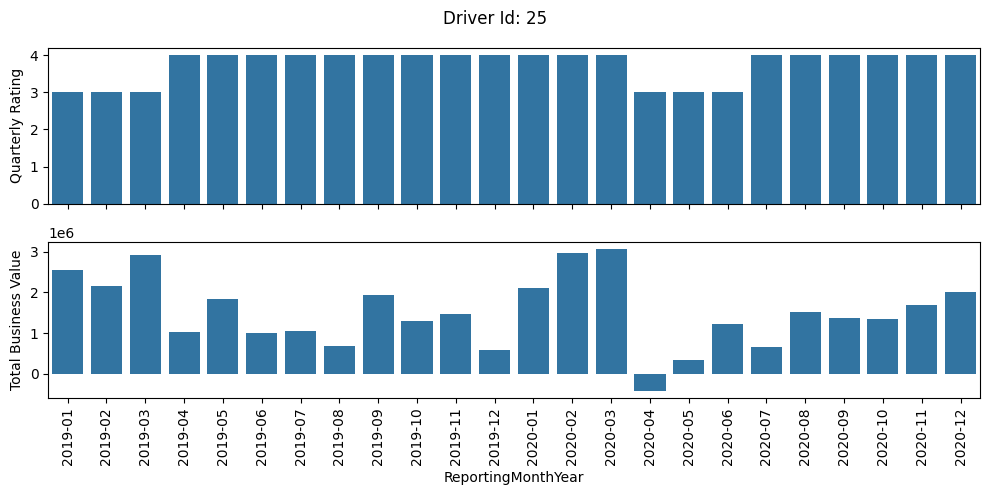

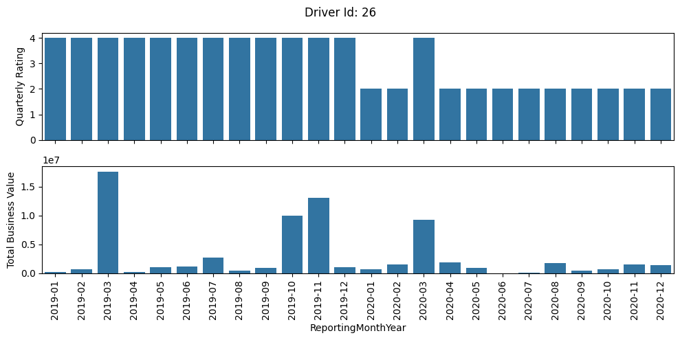

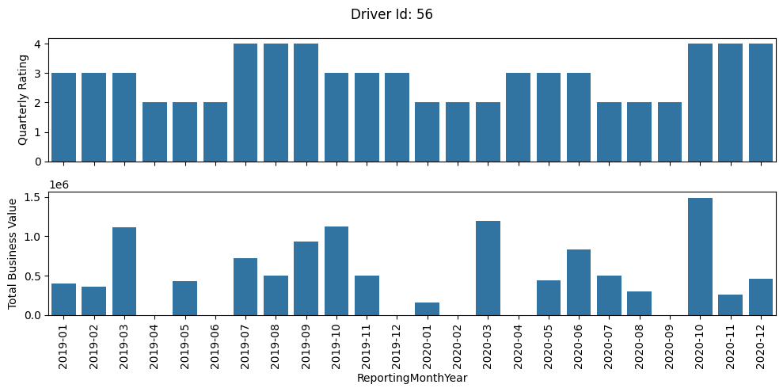

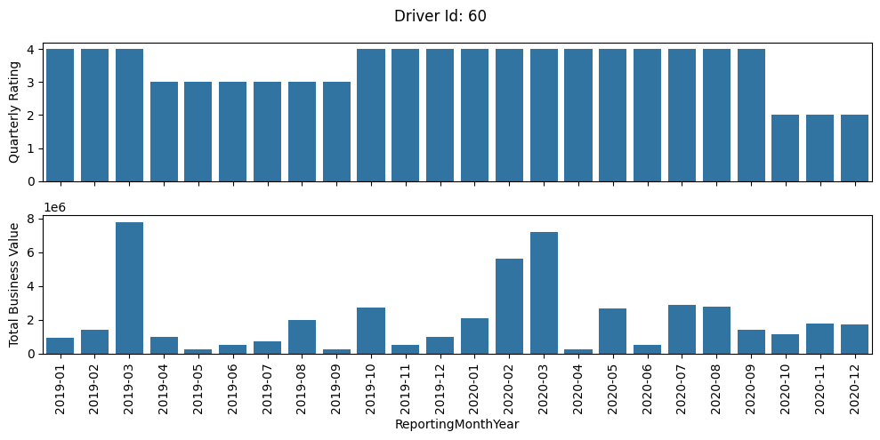

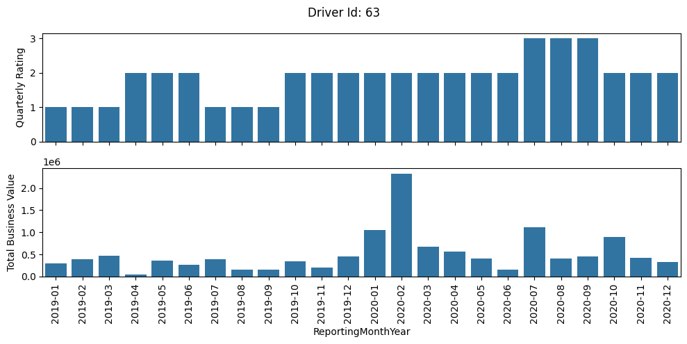

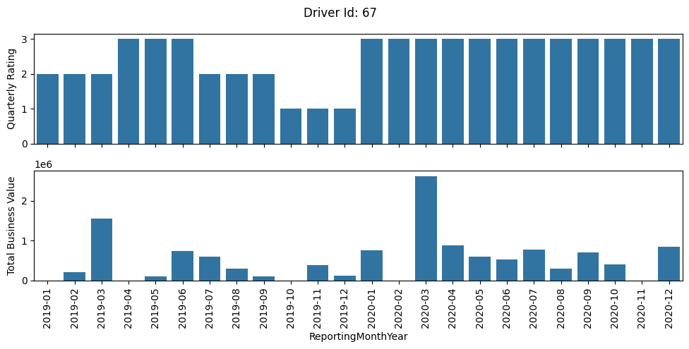

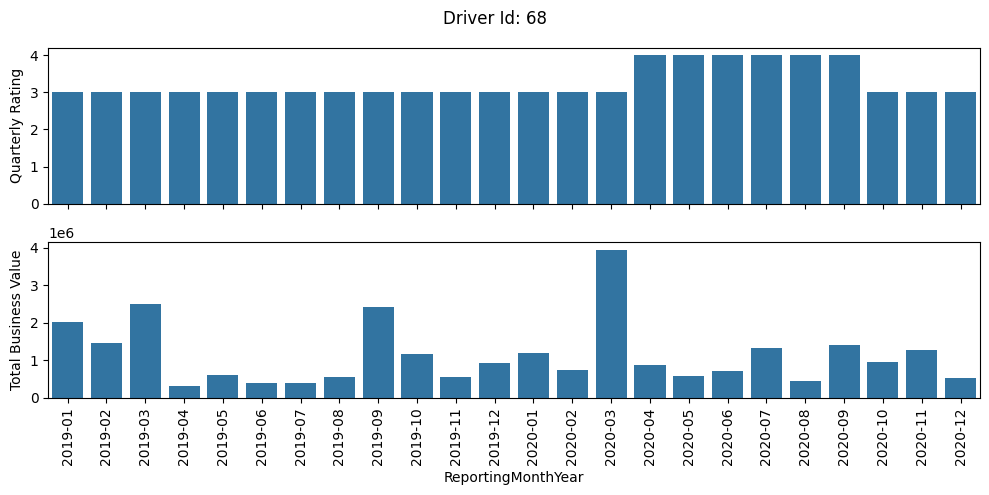

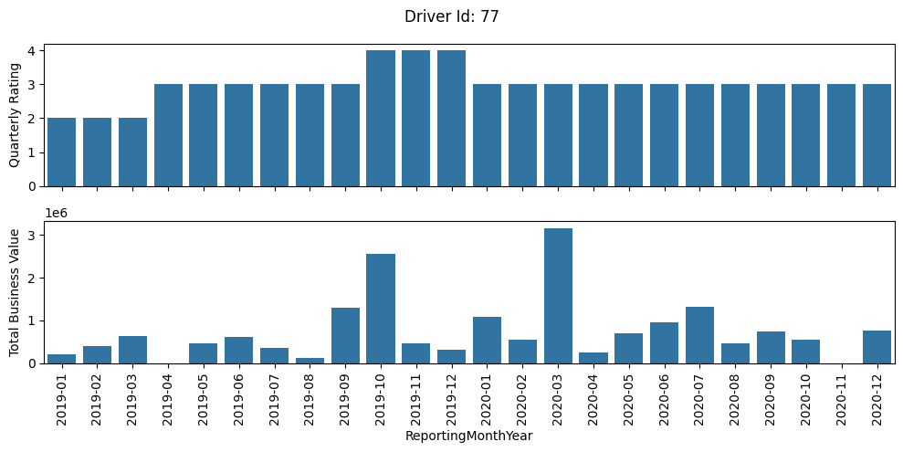

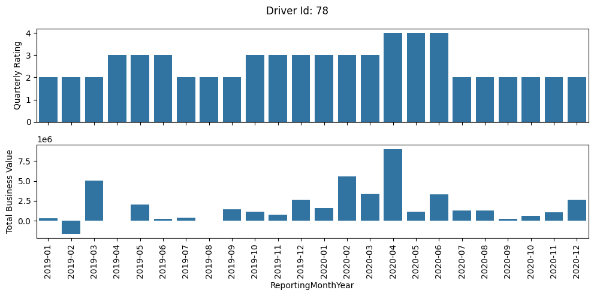

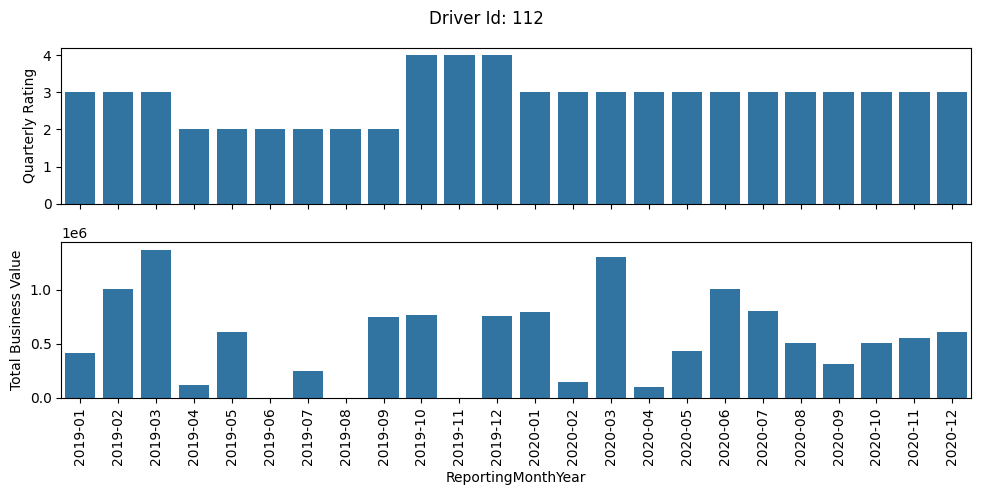

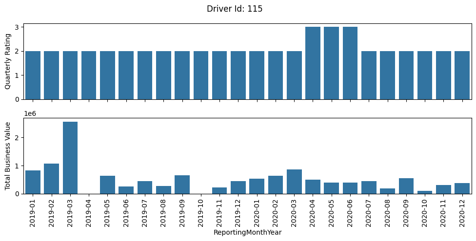

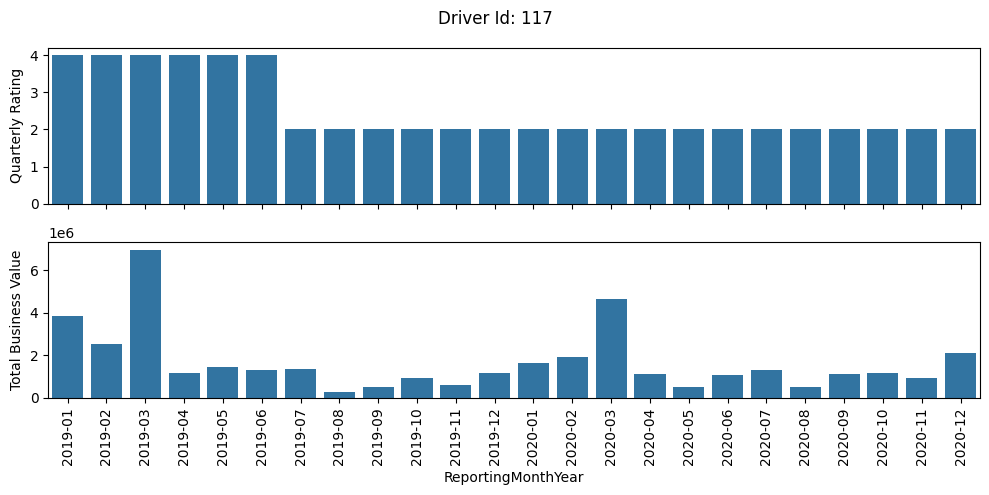

[8 more figures not shown]

```python
temp_driver_full_service_df = temp_df[temp_df['Driver_ID'].isin(drivers_with_2_year_service)]
num_of_drivers = 20
count=0
for driver_id in temp_driver_full_service_df['Driver_ID'].unique():
    if(count < num_of_drivers):
        count = count + 1
        sample_df = temp_driver_full_service_df[temp_driver_full_service_df['Driver_ID'] == driver_id]
        fig, axs = plt.subplots(2,1,figsize=(10, 5), sharex=True)
        sns.barplot(ax=axs[0], data=sample_df, x = 'ReportingMonthYear', y='Quarterly Rating')
        axs[0].tick_params(axis='x', rotation=90)
        sns.barplot(ax=axs[1], data=sample_df, x = 'ReportingMonthYear', y='Total Business Value')
        axs[1].tick_params(axis='x', rotation=90)
        fig.suptitle(f'Driver Id: {driver_id}')
        plt.tight_layout()
        plt.show()
    else:
        break
```

### Insight

- It can be observed that a significant drop in rating impacts the Total Business Value. Drop in rating demotivates the drivers, leading to accepting only a few rides or in somecases not accepting any rides and hence impacting the Total Business Value

## 4.3. Multivariate analysis

```python
driver_df['Gender'].replace({'Male':0, 'Female':1}, inplace=True)
driver_df['Education_Level'].replace({'Graduate':0, '10+':1, '12+':2}, inplace=True)
driver_df['City'] = driver_df['City'].str[1:]
```

```python
plt.figure(figsize=(15,10))
sns.heatmap(driver_df.drop(columns=['Driver_ID', 'Dateofjoining', 'LastWorkingDate', 'Income_Change']).corr(), annot=True)
plt.tight_layout()
plt.show()
```

[output not shown]

### Insight

- **Months of Service** and **Total Business Value** are highly correlated
- **Income** and **Grade** are highly correlated
- **Joining Designation** and **Grade** are highly correlated
- **Quarterly Rating** and **Months of Service** are highly correlated
- **Chrun** is decently correlated with **Quarterly Rating, Total Business Value, Months of Service**

# 5. Data Preprocessing

```python
driver_df.info()
```

```
<class 'pandas.core.frame.DataFrame'>
RangeIndex: 2381 entries, 0 to 2380
Data columns (total 19 columns):
 #   Column                     Non-Null Count  Dtype
---  ------                     --------------  -----
 0   Driver_ID                  2381 non-null   int64
 1   Months of Service          2381 non-null   int64
 2   Age                        2381 non-null   float64
 3   Gender                     2381 non-null   category
 4   City                       2381 non-null   object
 5   Education_Level            2381 non-null   category
 6   Income                     2381 non-null   int64
 7   Dateofjoining              2381 non-null   datetime64[ns]
 8   LastWorkingDate            1616 non-null   datetime64[ns]
 9   Joining Designation        2381 non-null   category
 10  Grade                      2381 non-null   category
 11  Total Business Value       2381 non-null   int64
 12  Quarterly Rating           2381 non-null   int64
 13  Churn                      2381 non-null   int64
 14  Income_Change              2381 non-null   int64
 15  Grade_Change               2381 non-null   int64
 16  Quarterly Rating_Change    2381 non-null   int64
 17  Quarterly Rating Improved  2381 non-null   int64
 18  Income_Raise               2381 non-null   int64
dtypes: category(4), datetime64[ns](2), float64(1), int64(11), object(1)
memory usage: 289.1+ KB
```

### Insight

- The columns **Driver_ID, Gender, City, Education_Level, Dateofjoining, LastWorkingDate** can be dropped as they do not contribute towards the driver churn rate

```python
driver_df.drop(columns=['Driver_ID', 'Gender', 'City', 'Education_Level', 'Dateofjoining', 'LastWorkingDate', 'Income_Change'], inplace=True)
driver_df['Quarterly Rating'] = driver_df['Quarterly Rating'].astype('category')
driver_df['Churn'] = driver_df['Churn'].astype('category')
driver_df['Grade_Change'] = driver_df['Grade_Change'].astype('category')
driver_df['Quarterly Rating_Change'] = driver_df['Quarterly Rating_Change'].astype('category')
driver_df['Income_Raise'] = driver_df['Income_Raise'].astype('category')
driver_df.head()
```

|  | Months of Service | Age | Income | Joining Designation | Grade | Total Business Value | Quarterly Rating | Churn | Grade_Change | Quarterly Rating_Change | Quarterly Rating Improved | Income_Raise |
| --- | --- | --- | --- | --- | --- | --- | --- | --- | --- | --- | --- | --- |
| 0 | 3 | 28.0 | 57387 | 1 | 1 | 1715580 | 2 | 1 | 0 | 0 | 0 | 0 |
| 1 | 2 | 31.0 | 67016 | 2 | 2 | 0 | 1 | 0 | 0 | 0 | 0 | 0 |
| 2 | 5 | 43.0 | 65603 | 2 | 2 | 350000 | 1 | 1 | 0 | 0 | 0 | 0 |
| 3 | 3 | 29.0 | 46368 | 1 | 1 | 120360 | 1 | 1 | 0 | 0 | 0 | 0 |
| 4 | 5 | 31.0 | 78728 | 3 | 3 | 1265000 | 2 | 0 | 0 | 1 | 1 | 0 |

```python
driver_df.duplicated().value_counts()
```

```
False    2381
Name: count, dtype: int64
```

### Insight

- There are no duplicates

## 5.1. Handling null values

```python
driver_df.isna().sum()
```

```
Months of Service            0
Age                          0
Income                       0
Joining Designation          0
Grade                        0
Total Business Value         0
Quarterly Rating             0
Churn                        0
Grade_Change                 0
Quarterly Rating_Change      0
Quarterly Rating Improved    0
Income_Raise                 0
dtype: int64
```

### Insight

- There are **no missing data or null values**

## 5.2. Outlier Treatment

```python
# helper function to detect outliers using IQR method
def detectOutliers_iqr(df):
    q1 = df.quantile(0.25)
    q3 = df.quantile(0.75)
    iqr = q3-q1
    lower_outliers = df[df<(q1-1.5*iqr)]
    higher_outliers = df[df>(q3+1.5*iqr)]
    return lower_outliers, higher_outliers

# helper function to detect outliers using standard deviation method
def detectOutliers_std(df):
    mean = df.mean()
    std = df.std()
    upper_limit = mean+(3*std)
    lower_limit = mean-(3*std)
    lower_outliers = df[df<lower_limit]
    higher_outliers = df[df>upper_limit]
    return lower_outliers, higher_outliers
```

```python
numerical_columns = driver_df.select_dtypes(include=np.number).columns
column_outlier_dictionary = {}
for column in numerical_columns:
    lower_outliers, higher_outliers = detectOutliers_iqr(driver_df[column])
    column_outlier_dictionary[column] = [lower_outliers, higher_outliers]
    #print('*'*50)
    #print(f'Outliers of \'{column}\' column are:')
    #print("Lower outliers:\n", lower_outliers)
    #print("Higher outliers:\n", higher_outliers)
    #print('*'*50, end="\n")
```

```python
for key, value in column_outlier_dictionary.items():
    print(f'The column \'{key}\' has {len(value[0]) + len(value[1])} outliers')
```

```
The column 'Months of Service' has 249 outliers
The column 'Age' has 25 outliers
The column 'Income' has 48 outliers
The column 'Total Business Value' has 336 outliers
The column 'Quarterly Rating Improved' has 358 outliers
```

```python
numerical_columns = driver_df.select_dtypes(include=np.number).columns
column_outlier_dictionary = {}
for column in numerical_columns:
    lower_outliers, higher_outliers = detectOutliers_std(driver_df[column])
    column_outlier_dictionary[column] = [lower_outliers, higher_outliers]
    #print('*'*50)
    #print(f'Outliers of \'{column}\' column are:')
    #print("Lower outliers:\n", lower_outliers)
    #print("Higher outliers:\n", higher_outliers)
    #print('*'*50, end="\n")
```

```python
for key, value in column_outlier_dictionary.items():
    print(f'The column \'{key}\' has {len(value[0]) + len(value[1])} outliers')
```

```
The column 'Months of Service' has 0 outliers
The column 'Age' has 14 outliers
The column 'Income' has 16 outliers
The column 'Total Business Value' has 64 outliers
The column 'Quarterly Rating Improved' has 0 outliers
```

### Insight

- I will **keep the outliers** in **Age** and **Income** columns as they are less in number
- I will **cap the outliers** in **Total Business Value** column as drivers with higher business value do not churn usually

```python
mean = driver_df['Total Business Value'].mean()
std = driver_df['Total Business Value'].std()
upper_limit = mean+(3*std)
driver_df['Total Business Value'] = driver_df['Total Business Value'].apply(lambda x: x if x <= upper_limit else upper_limit)
```

## 5.3. Multicollinearity Check

```python
features_df = driver_df.drop(columns=['Churn']) # Drop target column
features_df = features_df.drop(columns=features_df.select_dtypes(include='category').columns) # Drop category columns
features_df = sm.add_constant(features_df)  # Adding a constant column for the intercept
vif_df = pd.DataFrame()
vif_df['Features'] = features_df.columns
vif_df['VIF'] = [variance_inflation_factor(features_df.values, idx) for idx in range(len(features_df.columns))]
vif_df['VIF'] = round(vif_df['VIF'], 2)
vif_df = vif_df.sort_values(by='VIF', ascending=False)
vif_df
```

|  | Features | VIF |
| --- | --- | --- |
| 0 | const | 36.42 |
| 4 | Total Business Value | 3.99 |
| 1 | Months of Service | 3.83 |
| 3 | Income | 1.19 |
| 2 | Age | 1.12 |
| 5 | Quarterly Rating Improved | 1.09 |

## Insight

- Based on the above VIF scores, I can conclude that there are no multicolinear numerical features

## 5.4. Encode categorical variables

```python
final_df = driver_df.copy()
```

**Sepearte out target and feature columns**

```python
X = final_df.drop(columns=['Churn'])
y = final_df['Churn']
X.shape, y.shape
```

```
((2381, 11), (2381,))
```

**Encode target variable**

```python
y = y.astype(int)
```

**Encode features with just 2 classes as 0 or 1**

```python
X[['Grade_Change','Quarterly Rating_Change', 'Income_Raise']] = X[['Grade_Change','Quarterly Rating_Change', 'Income_Raise']].astype('int8')
```

**One-Hot-Encoding for remaining categorical features**

```python
X.info()
```

```
<class 'pandas.core.frame.DataFrame'>
RangeIndex: 2381 entries, 0 to 2380
Data columns (total 11 columns):
 #   Column                     Non-Null Count  Dtype
---  ------                     --------------  -----
 0   Months of Service          2381 non-null   int64
 1   Age                        2381 non-null   float64
 2   Income                     2381 non-null   int64
 3   Joining Designation        2381 non-null   category
 4   Grade                      2381 non-null   category
 5   Total Business Value       2381 non-null   float64
 6   Quarterly Rating           2381 non-null   category
 7   Grade_Change               2381 non-null   int8
 8   Quarterly Rating_Change    2381 non-null   int8
 9   Quarterly Rating Improved  2381 non-null   int64
 10  Income_Raise               2381 non-null   int8
dtypes: category(3), float64(2), int64(3), int8(3)
memory usage: 107.7 KB
```

```python
categorical_columns = X.select_dtypes(include='category').columns
categorical_columns
```

```
Index(['Joining Designation', 'Grade', 'Quarterly Rating'], dtype='object')
```

```python
encoder = OneHotEncoder(sparse_output=False)
encoded_data = encoder.fit_transform(X[categorical_columns])
encoded_df = pd.DataFrame(encoded_data, columns = encoder.get_feature_names_out(categorical_columns))
X = pd.concat([X, encoded_df], axis=1)
X.drop(columns = categorical_columns, inplace=True)
X.head()
```

|  | Months of Service | Age | Income | Total Business Value | Grade_Change | Quarterly Rating_Change | Quarterly Rating Improved | Income_Raise | Joining Designation_1 | Joining Designation_2 | ... | Joining Designation_5 | Grade_1 | Grade_2 | Grade_3 | Grade_4 | Grade_5 | Quarterly Rating_1 | Quarterly Rating_2 | Quarterly Rating_3 | Quarterly Rating_4 |
| --- | --- | --- | --- | --- | --- | --- | --- | --- | --- | --- | --- | --- | --- | --- | --- | --- | --- | --- | --- | --- | --- |
| 0 | 3 | 28.0 | 57387 | 1715580.0 | 0 | 0 | 0 | 0 | 1.0 | 0.0 | ... | 0.0 | 1.0 | 0.0 | 0.0 | 0.0 | 0.0 | 0.0 | 1.0 | 0.0 | 0.0 |
| 1 | 2 | 31.0 | 67016 | 0.0 | 0 | 0 | 0 | 0 | 0.0 | 1.0 | ... | 0.0 | 0.0 | 1.0 | 0.0 | 0.0 | 0.0 | 1.0 | 0.0 | 0.0 | 0.0 |
| 2 | 5 | 43.0 | 65603 | 350000.0 | 0 | 0 | 0 | 0 | 0.0 | 1.0 | ... | 0.0 | 0.0 | 1.0 | 0.0 | 0.0 | 0.0 | 1.0 | 0.0 | 0.0 | 0.0 |
| 3 | 3 | 29.0 | 46368 | 120360.0 | 0 | 0 | 0 | 0 | 1.0 | 0.0 | ... | 0.0 | 1.0 | 0.0 | 0.0 | 0.0 | 0.0 | 1.0 | 0.0 | 0.0 | 0.0 |
| 4 | 5 | 31.0 | 78728 | 1265000.0 | 0 | 1 | 1 | 0 | 0.0 | 0.0 | ... | 0.0 | 0.0 | 0.0 | 1.0 | 0.0 | 0.0 | 0.0 | 1.0 | 0.0 | 0.0 |

5 rows × 22 columns

# 6. Model building

## 6.1. Train-test split

```python
X_train, X_test, y_train, y_test = train_test_split(X, y, test_size=0.2, random_state=0)
X_train.shape, X_test.shape, y_train.shape, y_test.shape
```

```
((1904, 22), (477, 22), (1904,), (477,))
```

## 6.2. Perform data normalization/standardization

Data normalization/standardization is required so that features with higher scales do not dominate the model's performance. Hence all features should have same scale

**Data before scaling**

```python
X_train.head()
```

|  | Months of Service | Age | Income | Total Business Value | Grade_Change | Quarterly Rating_Change | Quarterly Rating Improved | Income_Raise | Joining Designation_1 | Joining Designation_2 | ... | Joining Designation_5 | Grade_1 | Grade_2 | Grade_3 | Grade_4 | Grade_5 | Quarterly Rating_1 | Quarterly Rating_2 | Quarterly Rating_3 | Quarterly Rating_4 |
| --- | --- | --- | --- | --- | --- | --- | --- | --- | --- | --- | --- | --- | --- | --- | --- | --- | --- | --- | --- | --- | --- |
| 2236 | 7 | 28.0 | 57164 | 1092560.0 | 0 | 0 | 0 | 0 | 0.0 | 1.0 | ... | 0.0 | 0.0 | 1.0 | 0.0 | 0.0 | 0.0 | 1.0 | 0.0 | 0.0 | 0.0 |
| 6 | 1 | 28.0 | 42172 | 0.0 | 0 | 0 | 0 | 0 | 1.0 | 0.0 | ... | 0.0 | 1.0 | 0.0 | 0.0 | 0.0 | 0.0 | 1.0 | 0.0 | 0.0 | 0.0 |
| 1818 | 1 | 29.0 | 43989 | 0.0 | 0 | 0 | 0 | 0 | 1.0 | 0.0 | ... | 0.0 | 1.0 | 0.0 | 0.0 | 0.0 | 0.0 | 1.0 | 0.0 | 0.0 | 0.0 |
| 1534 | 7 | 40.0 | 59636 | 2589640.0 | 0 | 0 | 0 | 0 | 0.0 | 0.0 | ... | 0.0 | 0.0 | 0.0 | 1.0 | 0.0 | 0.0 | 1.0 | 0.0 | 0.0 | 0.0 |
| 2123 | 6 | 25.0 | 29052 | 2172260.0 | 0 | 0 | 0 | 0 | 1.0 | 0.0 | ... | 0.0 | 1.0 | 0.0 | 0.0 | 0.0 | 0.0 | 1.0 | 0.0 | 0.0 | 0.0 |

5 rows × 22 columns

```python
min_max_scaler = MinMaxScaler()
# Fit min_max_scaler to training data
min_max_scaler.fit(X_train)
# Scale the training and testing data
X_train = pd.DataFrame(min_max_scaler.transform(X_train), columns=X_train.columns)
X_test = pd.DataFrame(min_max_scaler.transform(X_test), columns=X_test.columns)
```

**Data after scaling**

```python
X_train.head()
```

|  | Months of Service | Age | Income | Total Business Value | Grade_Change | Quarterly Rating_Change | Quarterly Rating Improved | Income_Raise | Joining Designation_1 | Joining Designation_2 | ... | Joining Designation_5 | Grade_1 | Grade_2 | Grade_3 | Grade_4 | Grade_5 | Quarterly Rating_1 | Quarterly Rating_2 | Quarterly Rating_3 | Quarterly Rating_4 |
| --- | --- | --- | --- | --- | --- | --- | --- | --- | --- | --- | --- | --- | --- | --- | --- | --- | --- | --- | --- | --- | --- |
| 0 | 0.260870 | 0.205882 | 0.261253 | 0.074297 | 0.0 | 0.5 | 0.0 | 0.0 | 0.0 | 1.0 | ... | 0.0 | 0.0 | 1.0 | 0.0 | 0.0 | 0.0 | 1.0 | 0.0 | 0.0 | 0.0 |
| 1 | 0.000000 | 0.205882 | 0.176872 | 0.041541 | 0.0 | 0.5 | 0.0 | 0.0 | 1.0 | 0.0 | ... | 0.0 | 1.0 | 0.0 | 0.0 | 0.0 | 0.0 | 1.0 | 0.0 | 0.0 | 0.0 |
| 2 | 0.000000 | 0.235294 | 0.187099 | 0.041541 | 0.0 | 0.5 | 0.0 | 0.0 | 1.0 | 0.0 | ... | 0.0 | 1.0 | 0.0 | 0.0 | 0.0 | 0.0 | 1.0 | 0.0 | 0.0 | 0.0 |
| 3 | 0.260870 | 0.558824 | 0.275166 | 0.119183 | 0.0 | 0.5 | 0.0 | 0.0 | 0.0 | 0.0 | ... | 0.0 | 0.0 | 0.0 | 1.0 | 0.0 | 0.0 | 1.0 | 0.0 | 0.0 | 0.0 |
| 4 | 0.217391 | 0.117647 | 0.103028 | 0.106669 | 0.0 | 0.5 | 0.0 | 0.0 | 1.0 | 0.0 | ... | 0.0 | 1.0 | 0.0 | 0.0 | 0.0 | 0.0 | 1.0 | 0.0 | 0.0 | 0.0 |

5 rows × 22 columns

**Check for imbalance in target class**

```python
y_train.value_counts(normalize=True)*100
```

```
Churn
1    68.644958
0    31.355042
Name: proportion, dtype: float64
```

We can see a clear imbalance in the target class with **1** being **~69%** and **0** being **~31%**. Hence, I will use **SMOTE** to fix this imbalance

```python
sm = SMOTE(random_state=0)
X_train, y_train = sm.fit_resample(X_train, y_train)
y_train.value_counts(normalize=True)*100
```

```
Churn
1    50.0
0    50.0
Name: proportion, dtype: float64
```

## 6.3. Ensemble Learning: Bagging - RandomForestClassifier

A random forest is a meta estimator that fits a number of decision tree classifiers on various sub-samples of the dataset and uses averaging to improve the predictive accuracy and control over-fitting.  
The hyper-parameters of the random forest classifier will be selected using grid search cross validation

```python
# Define parameter grid
param_grid = {
    'n_estimators': list(range(100, 1000, 100)),
    'max_features': ['sqrt', 'log2'],
    'max_depth': list(range(10, 100, 10)),
    'min_samples_split': list(range(2, 10, 1))
}

# Initialize classifier and RandomizedSearchCV
rf = RandomForestClassifier()
rf_random = GridSearchCV(estimator=rf, param_grid=param_grid, cv=3, verbose=2, n_jobs=-1)

# Fit the model
rf_random.fit(X_train, y_train)

# Evaluate best parameters
print("Best parameters found: ", rf_random.best_params_)
```

[output not shown]

[output cut: 1891 more lines]

[output not shown]

```python
color = '\033[91m'
bold = '\033[1m'
end = '\033[0m'
# Predict and evaluate performance
y_true = y_train
y_pred = rf_random.predict(X_train)
print(color + bold + "Train data:" + color + end)
print("Accuracy: ", accuracy_score(y_true, y_pred))
print("Classification Report:\n", classification_report(y_true, y_pred))
y_true = y_test
y_pred = rf_random.predict(X_test)
print(color + bold + "Test data:" + color + end)
print("Accuracy: ", accuracy_score(y_true, y_pred))
print("Classification Report:\n", classification_report(y_true, y_pred))
```

```
Train data:
Accuracy:  1.0
Classification Report:
               precision    recall  f1-score   support

           0       1.00      1.00      1.00      1307
           1       1.00      1.00      1.00      1307

    accuracy                           1.00      2614
   macro avg       1.00      1.00      1.00      2614
weighted avg       1.00      1.00      1.00      2614

Test data:
Accuracy:  0.7777777777777778
Classification Report:
               precision    recall  f1-score   support

           0       0.70      0.64      0.67       168
           1       0.81      0.85      0.83       309

    accuracy                           0.78       477
   macro avg       0.76      0.75      0.75       477
weighted avg       0.77      0.78      0.78       477
```

## Insight

- The training accuracy is 1 whereas testing accuracy is 0.778. This is a case of **overfitting**.
- The best parameters found are well within the provided range

### 6.3.1 Feature Importance Plot

```python
def plot_feature_importance(estimator, features):
    # Extract feature importances
    importances = estimator.feature_importances_

    # Create a DatafRame for plotting
    feature_importance_df = pd.DataFrame({'Feature':features, 'Importance':importances})
    feature_importance_df = feature_importance_df.sort_values(by='Importance', ascending=False)

    # Plot feature importance
    plt.figure(figsize=(8,5))
    sns.barplot(data=feature_importance_df, x='Importance', y='Feature')
    plt.title('Feature Importance')
    plt.show()
```

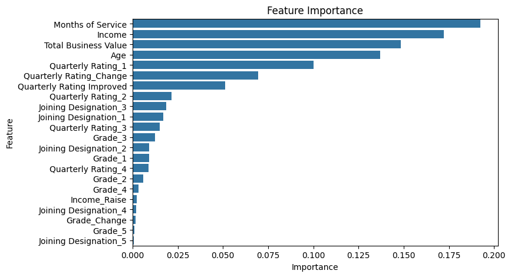

```python
plot_feature_importance(rf_random.best_estimator_, X_train.columns)
```

### 6.3.2 Confusion Matrix

```python
def display_confusion_matrix(y_test, y_pred):
    # Compute confusion matrix
    cm = confusion_matrix(y_test, y_pred)

    # Plot confusion matrix
    disp = ConfusionMatrixDisplay(confusion_matrix=cm)
    disp.plot(cmap=plt.cm.Blues)
    plt.title('Confusion Matrix')
    plt.show()
```

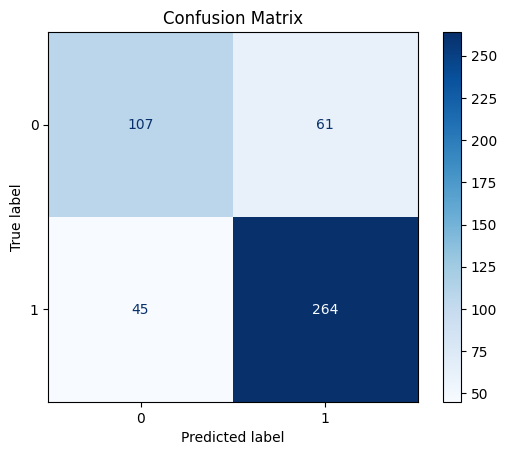

```python
display_confusion_matrix(y_test, y_pred)
```

### 6.3.3 ROC Curve

```python
def plot_roc_curve(estimator, X_train, X_test, y_train, y_test):
    # Binarize the output
    y_test_binarized = label_binarize(y_test, classes=[0, 1, 2])
    n_classes = y_test_binarized.shape[1]-1

    # Compute ROC curve and ROC area for each class
    classifier = OneVsRestClassifier(estimator)
    y_score = classifier.fit(X_train, y_train).predict_proba(X_test)

    fpr = dict()
    tpr = dict()
    roc_auc = dict()
    for i in range(n_classes):
        fpr[i], tpr[i], _ = roc_curve(y_test_binarized[:, i], y_score[:, i])
        roc_auc[i] = auc(fpr[i], tpr[i])

    # Plot ROC curve for each class
    plt.figure(figsize=(5, 5))
    for i in range(n_classes):
        plt.plot(fpr[i], tpr[i], label='ROC curve of class {0} (area = {1:0.2f})'.format(i, roc_auc[i]))
    plt.plot([0, 1], [0, 1], 'k--')
    plt.xlim([0.0, 1.0])
    plt.ylim([0.0, 1.05])
    plt.xlabel('False Positive Rate')
    plt.ylabel('True Positive Rate')
    plt.title('ROC Curve')
    plt.legend(loc='lower right')
    plt.show()
```

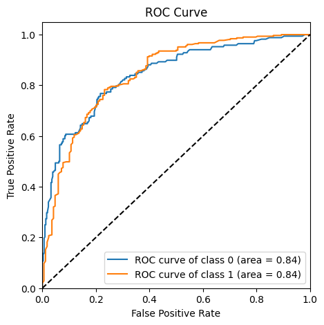

```python
plot_roc_curve(rf_random.best_estimator_, X_train, X_test, y_train, y_test)
```

### 6.3.4 Precision-Recall Curve

```python
def plot_pr_curve(estimator, X_train, X_test, y_train, y_test):
    # Binarize the output
    y_test_binarized = label_binarize(y_test, classes=[0, 1, 2])
    n_classes = y_test_binarized.shape[1]-1

    # Compute ROC curve and ROC area for each class
    classifier = OneVsRestClassifier(estimator)
    y_score = classifier.fit(X_train, y_train).predict_proba(X_test)

    # For each class
    precision = dict()
    recall = dict()
    average_precision = dict()
    for i in range(n_classes):
        precision[i], recall[i], _ = precision_recall_curve(y_test_binarized[:, i], y_score[:, i])
        average_precision[i] = average_precision_score(y_test_binarized[:, i], y_score[:, i])

    # Plot Precision-Recall curve for each class
    plt.figure(figsize=(5, 5))
    for i in range(n_classes):
        plt.plot(recall[i], precision[i], label='PR curve of class {0} (area = {1:0.2f})'.format(i, average_precision[i]))

    plt.xlabel('Recall')
    plt.ylabel('Precision')
    plt.title('Precision-Recall Curve')
    plt.legend(loc='lower right')
    plt.show()
```

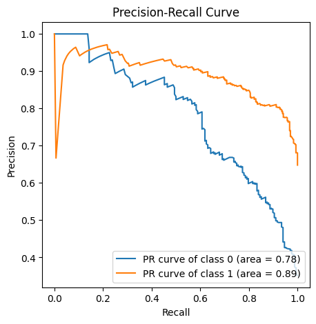

```python
plot_pr_curve(rf_random.best_estimator_, X_train, X_test, y_train, y_test)
```

## 6.4. Ensemble Learning: Boosting - GradientBoostingClassifier

This algorithm builds an additive model in a forward stage-wise fashion; it allows for the optimization of arbitrary differentiable loss functions. In each stage n_classes_ regression trees are fit on the negative gradient of the loss function, e.g. binary or multiclass log loss.  
The hyper-parameters of the GradientBoostingClassifier will be selected using random search cross validation

```python
# Define parameter grid
param_grid = {
    'n_estimators': np.arange(100, 1001, 100),
    'learning_rate': np.logspace(-3, 0, 10),
    'max_depth': np.arange(3, 11, 1),
    'min_samples_split': np.arange(2, 21, 2),
    'min_samples_leaf': np.arange(1, 21, 2),
    'subsample': np.linspace(0.5, 1.0, 6)
}

# Initialize classifier and RandomizedSearchCV
gb = GradientBoostingClassifier()
gb_random = RandomizedSearchCV(estimator=gb, param_distributions=param_grid,
                                n_iter=300, cv=3, verbose=2, random_state=42, n_jobs=-1)

# Fit the model
gb_random.fit(X_train, y_train)

# Evaluate best parameters
print("Best parameters found for GradientBoostingClassifier: ", gb_random.best_params_)
```

[output not shown]

[output cut: 1873 more lines]

[output not shown]

```python
color = '\033[91m'
bold = '\033[1m'
end = '\033[0m'
# Predict and evaluate performance
y_true = y_train
y_pred = gb_random.predict(X_train)
print(color + bold + "Train data:" + color + end)
print("Accuracy: ", accuracy_score(y_true, y_pred))
print("Classification Report:\n", classification_report(y_true, y_pred))
y_true = y_test
y_pred = gb_random.predict(X_test)
print(color + bold + "Test data:" + color + end)
print("Accuracy: ", accuracy_score(y_true, y_pred))
print("Classification Report:\n", classification_report(y_true, y_pred))
```

```
Train data:
Accuracy:  0.9835501147666411
Classification Report:
               precision    recall  f1-score   support

           0       0.99      0.97      0.98      1307
           1       0.97      0.99      0.98      1307

    accuracy                           0.98      2614
   macro avg       0.98      0.98      0.98      2614
weighted avg       0.98      0.98      0.98      2614

Test data:
Accuracy:  0.7861635220125787
Classification Report:
               precision    recall  f1-score   support

           0       0.72      0.64      0.68       168
           1       0.81      0.87      0.84       309

    accuracy                           0.79       477
   macro avg       0.77      0.75      0.76       477
weighted avg       0.78      0.79      0.78       477
```

## Insight

### 6.4.1 Performance

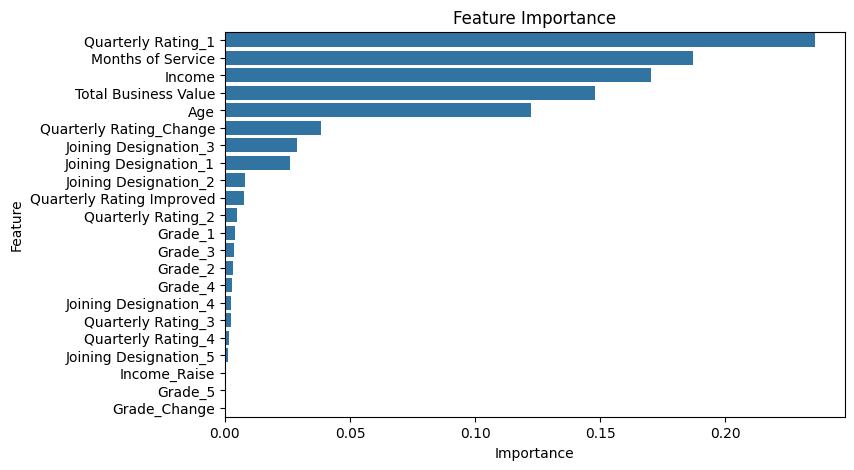

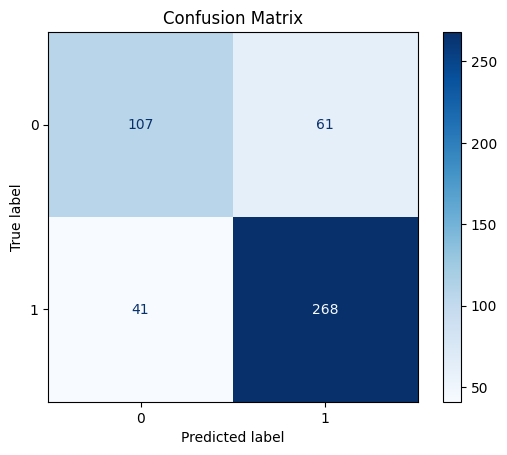

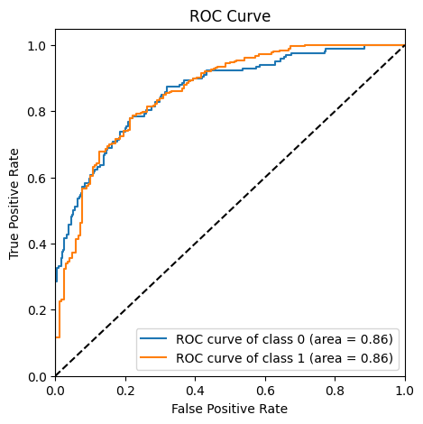

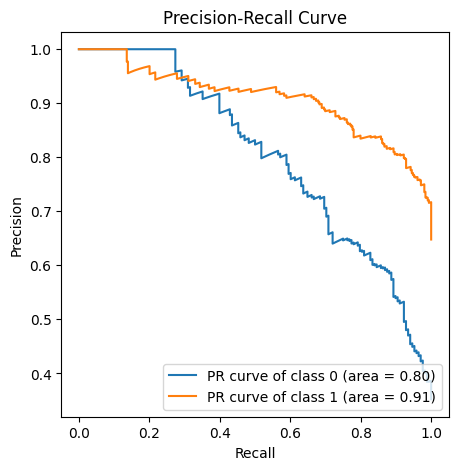

```python
plot_feature_importance(gb_random.best_estimator_, X_train.columns)
display_confusion_matrix(y_test, y_pred)
plot_roc_curve(gb_random.best_estimator_, X_train, X_test, y_train, y_test)
plot_pr_curve(gb_random.best_estimator_, X_train, X_test, y_train, y_test)
```

## 6.5. Ensemble Learning: Boosting - XGBClassifier

XGBClassifier is a highly optimized version of GBM. It includes regularization to prevent overfitting and various other enhancements.  
The hyper-parameters of the XGBClassifier will be selected using random search cross validation

```python
# Define parameter grid
param_grid = {
    'n_estimators': np.arange(100, 1001, 100),
    'learning_rate': np.logspace(-3, 0, 10),
    'max_depth': np.arange(3, 11, 1),
    'min_child_weight': np.arange(1, 11, 1),
    'gamma': np.logspace(-3, 1, 10),
    'subsample': np.linspace(0.5, 1.0, 6),
    'colsample_bytree': np.linspace(0.5, 1.0, 6)
}


# Initialize classifier and RandomizedSearchCV
xgb = XGBClassifier(eval_metric='mlogloss')
xgb_random = RandomizedSearchCV(estimator=xgb, param_distributions=param_grid,
                                n_iter=300, cv=3, verbose=2, random_state=42, n_jobs=-1)

# Fit the model
xgb_random.fit(X_train, y_train)

# Evaluate best parameters
print("Best parameters found for XGBoost: ", xgb_random.best_params_)
```

[output not shown]

[output cut: 279 more lines]

[output not shown]

```python
color = '\033[91m'
bold = '\033[1m'
end = '\033[0m'
# Predict and evaluate performance
y_true = y_train
y_pred = xgb_random.predict(X_train)
print(color + bold + "Train data:" + color + end)
print("Accuracy: ", accuracy_score(y_true, y_pred))
print("Classification Report:\n", classification_report(y_true, y_pred))
y_true = y_test
y_pred = xgb_random.predict(X_test)
print(color + bold + "Test data:" + color + end)
print("Accuracy: ", accuracy_score(y_true, y_pred))
print("Classification Report:\n", classification_report(y_true, y_pred))
```

```
Train data:
Accuracy:  1.0
Classification Report:
               precision    recall  f1-score   support

           0       1.00      1.00      1.00      1307
           1       1.00      1.00      1.00      1307

    accuracy                           1.00      2614
   macro avg       1.00      1.00      1.00      2614
weighted avg       1.00      1.00      1.00      2614

Test data:
Accuracy:  0.7714884696016772
Classification Report:
               precision    recall  f1-score   support

           0       0.68      0.66      0.67       168
           1       0.82      0.83      0.83       309

    accuracy                           0.77       477
   macro avg       0.75      0.75      0.75       477
weighted avg       0.77      0.77      0.77       477
```

## Insight

### 6.5.1 Performance

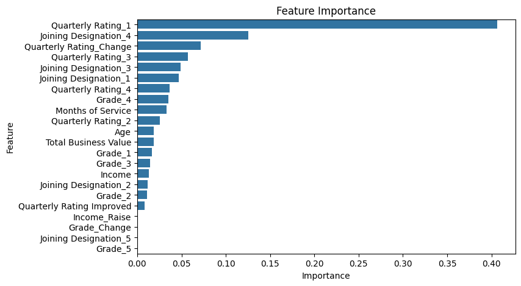

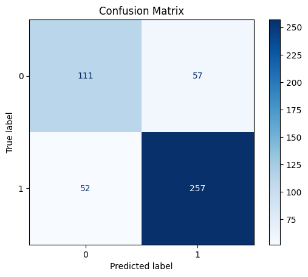

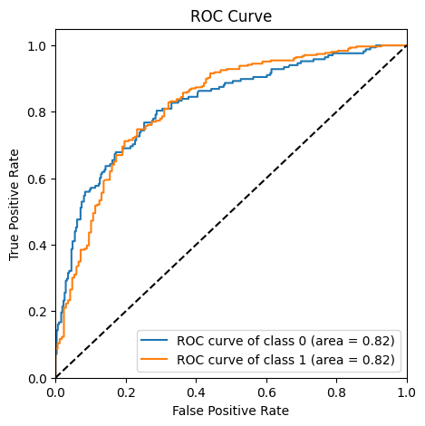

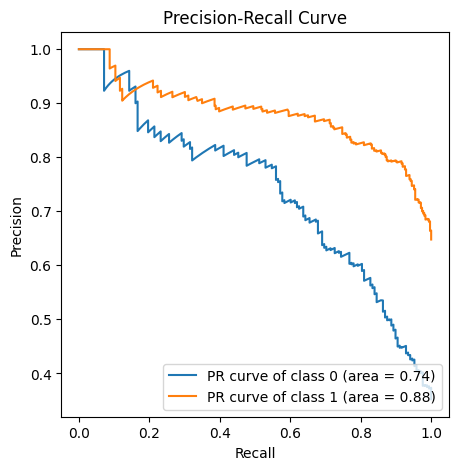

[output not shown]

[output cut: 1308 more lines]

```python
plot_feature_importance(xgb_random.best_estimator_, X_train.columns)
display_confusion_matrix(y_test, y_pred)
plot_roc_curve(xgb_random.best_estimator_, X_train, X_test, y_train, y_test)
plot_pr_curve(xgb_random.best_estimator_, X_train, X_test, y_train, y_test)
```

# 7. Insights

- **Most** of the drivers are in the age group of **30 to 35**
- **59%** of the drivers are **Male** and remaining **41%** are **Female**
- City **C20** has the **maximum** number of **drivers**
- Maximum number of drivers joined in the year **2020** and in the month of **July**
- 1026 drivers have a **joining designation of 1**
- Maximum number of drivers have a **grade of 2**
- **Majority** of the drivers have a very **low quarterly rating of 1**
- There are **no drivers** with quarterly rating of **5**
- **1616** drivers have **churned**, which is around **68%**
- The **median income** of drivers who have **churned** is **lesser** than that of the drivers who have not churned
- The **churn rate** is **very less** in drivers whose **income has raised**
- The **churn rate** is **very less** in drivers whose **grade has raised**
- The **churn rate** is **very less** in drivers whose **Quarterly rating has increased**

# 8. Recommendation

- The quartely rating has been the top contibutor on deciding if a driver will churn or not. As the ratings are given by the customers to the driver, Ola should urge all customers to rate the drivers on time. Ola should provide incentives/points to the customers to encourage timely rating.
- Ola should make sure that the income of deserving drivers should be increased every 6 months, if not every quarter, to encourage drivers to stay
- Long service awards/bonuses should be given to drivers to keep them motivated
- Special trainings should be given to drivers on how to handle different customers and different situations so that the customers always provide positive ratings

# 9. Questionnaire

### 9.1 What percentage of drivers have received a quarterly rating of 5?

**Ans:** No drivers have received a quarterly rating of 5

### 9.2 Comment on the correlation between Age and Quarterly Rating.

**Ans:** Age and Quarterly rating do not have much correlation. They have a small correlation value of 0.15

### 9.3 Name the city which showed the most improvement in Quarterly Rating over the past year

**Ans:** The city C29 shows most improvement in Quarterly Rating in 2020 compared to 2019

### 9.4 Drivers with a Grade of ‘A’ are more likely to have a higher Total Business Value. (T/F)

**Ans:** Yes, the mean of Total Business Value of drivers with grade 5(or A) is higher than those with other grades

### 9.5 If a driver's Quarterly Rating drops significantly, how does it impact their Total Business Value in the subsequent period?

**Ans:** A significant drop in rating leads to dip in the Total Business Value in the subsequesnt period. Drop in rating demotivates the drivers, leading to accepting only a few rides or in somecases not accepting any rides and hence impacting the Total Business Value

### 9.6 From Ola's perspective, which metric should be the primary focus for driver retention? 1. ROC AUC, 2. Precision, 3. Recall, 4. F1 Score

**Ans:** Recall. It is ok if the model predicts most drivers as **Churn** but it should not predict **Churn** drivers as **Not Churn**

### 9.7 How does the gap in precision and recall affect Ola's relationship with its drivers and customers?

**Ans:** Gap in the precision and recall implies that the False Negatives and False Positives values are very different. If more instances of Churn are misclassified as Not Churn, then the customers may get drives who are not-motived/unsatisfied leading to bad customer experience. On the other hand if more instances of Not Churn are misclassified as Churn, then the good performing drivers will be neglected leading to driver dissatification.

### 9.8 Besides the obvious features like "Number of Rides", which lesser-discussed features might have a strong impact on a driver's Quarterly Rating?

**Ans:**

1. Customers not providing timely rating or providing false rating has a strong impact on high performing drivers and their quarterly rating.\
2. Lack of training to the driver on handling different situation can also impact their quarterly rating. Not all customers are same, so the driver needs to adapt his behaviour as per the customer.

### 9.9 Will the driver's performance be affected by the City they operate in? (Yes/No)

**Ans:** Yes, it might be the case that the people(customers) of a city are of a particular mindset. The people of a city could be more accomodative and provide good ratings always and people of a different city could get irriated easily and provide bad ratings

### 9.10 Analyze any seasonality in the driver's ratings. Do certain times of the year correspond to higher or lower ratings, and why might that be?

**Ans:** Yes, there is a seasonality in the driver's rating. The ratings dip in Q2 and then shoot up in Q3. This could be becuase of the holiday season in Q2 when many people move out of the cities for vacation and hence less usage of cabs.